# Divvy Bikes Membership Ride Analysis 2022

Bret Reinig

# 1 Summary

## 1.1 Scenario

You are a junior data analyst working in the marketing analyst team at Cyclistic, a bike-share company in Chicago. The director of marketing believes the company’s future success depends on maximizing the number of annual memberships. Therefore, your team wants to understand how casual riders and annual members use Cyclistic bikes differently. From these insights, your team will design a new marketing strategy to convert casual riders into annual members. But first, Cyclistic executives must approve your recommendations, so they must be backed up with compelling data insights and professional data visualizations.

## 1.2 Characters and teams

- Cyclistic: A bike-share program that features more than 5,800 bicycles and 600 docking stations. Cyclistic sets itself apart by also offering reclining bikes, hand tricycles, and cargo bikes, making bike-share more inclusive to people with disabilities and riders who can’t use a standard two-wheeled bike. The majority of riders opt for traditional bikes; about 8% of riders use the assistive options. Cyclistic users are more likely to ride for leisure, but about 30% use them to commute to work each day.
- Lily Moreno: The director of marketing and your manager. Moreno is responsible for the development of campaigns and initiatives to promote the bike-share program. These may include email, social media, and other channels.
- Cyclistic marketing analytics team: A team of data analysts who are responsible for collecting, analyzing, and reporting data that helps guide Cyclistic marketing strategy. You joined this team six months ago and have been busy learning about Cyclistic’s mission and business goals — as well as how you, as a junior data analyst, can help Cyclistic achieve them.
- Cyclistic executive team: The notoriously detail-oriented executive team will decide whether to approve the recommended marketing program.

## 1.3 About the company

This projects scenario, characters, and the clyclistic bike company are fictional.

For this analysis I will be using Divvy Bikes public data set.

Divvy is Chicagoland’s bike share system across Chicago and Evanston. Divvy provides residents and visitors with a convenient, fun and affordable transportation option for getting around and exploring Chicago.

Divvy, like other bike share systems, consists of a fleet of specially-designed, sturdy and durable bikes that are locked into a network of docking stations throughout the region. The bikes can be unlocked from one station and returned to any other station in the system. People use bike share to explore Chicago, commute to work or school, run errands, get to appointments or social engagements, and more.

Divvy is available for use 24 hours/day, 7 days/week, 365 days/year, and riders have access to all bikes and stations across the system.  
-[ride.divvybikes.com/about](https://ride.divvybikes.com/about#:~:text=Divvy%20provides%20residents%20and%20visitors,docking%20stations%20throughout%20the%20region.)

# 2 Ask

## 2.1 Business Task

1. How do annual members and casual riders use Divvy bikes differently?
2. Why would casual riders buy Divvy annual memberships?
3. How can Divvy use digital media to influence casual riders to become members?

# 3 Prepare

For this project I will be looking into Divvy Bikes user data, since purchased from Cyclistic to find relevant trends comparing membership riders to the casual rider. All data was sourced directly from [divvybikes.com](https://divvy-tripdata.s3.amazonaws.com/index.html) via public licensing. The data from December 2021 to November 2022 was downloaded as a separate CSV file for each month. From there Excel was used to create two new columns for each file, `ride_length` and `day_of_week`.

*ride_length* is the calculated seconds each ride took and was created via the formula:

```
=round((ended_at - started_at)*86400, 0)
```

The 86400 represents the number of seconds in a day and is used to output the ride_length in seconds.

*day_of_week* returns the day of the week in number format where Sunday equals day 1 and Saturday equals 7.  
The formula to produce this was:

```
=weekday(started_at, 1)
```

The monthly data will consist of the following columns:

| Column Name | Data Type | Description |
| --- | --- | --- |
| ride_id | Character | Ride Identification number |
| rideable_type | Character | Type of bike |
| day_of_week | Double | The day of the week in numeric form, where 1 is Sunday and Saturday is 7 |
| started_at | Datetime | The date and time the ride began at |
| ended_at | Datetime | The date and time the ride ended at |
| ride_length | Double | The length of ride in seconds |
| start_station_name | Character | Start Station Name |
| start_station_id | Character | The alphanumeric name given to identify the start station |
| end_station_name | Character | End station name |
| end_station_id | Character | The alphanumeric name given to identify the start station |
| start_lat | Double | Starting latitude |
| start_lng | Double | Starting longitude |
| end_lat | Double | Ending latitude |
| end_lng | Double | Ending longitude |
| member_casual | Character | The type of rider |

## 3.1 About the Data set

The data was downloaded as 12 separate CSV files directly from the divvy bikes website. It is organized by the month, covering from December 2021 through November 2022. There are also 2 separate excel files created by myself to illustrate pricing talking points.

Divvy Bikes website refers to two different bike models, the electric and classic. However the data revealed a third type of bike, the “docked_bike” that accounted for ~3% of total rides. Since no further information could be found on these bikes their data was omitted from this analysis.

## 3.2 Licensing

License. Bikeshare hereby grants to you a non-exclusive, royalty-free, limited, perpetual license to access, reproduce, analyze, copy, modify, distribute in your product or service and use the Data for any lawful purpose (“License”).

## 3.3 Data Credibility and Integrity

Does the data *ROCCC*?

- Reliable: The data is reliable, it’s unbiased and has not been modified.
- Original: The data is produced from the company app and hardware and is not altered by the user so it is considered original.
- Comprehensive: What was needed to complete an analysis was present in the data, however more detailed information as to what types of trips the casual riders took would have been complimentary to the analyses, such as single ride or day pass.
- Current: The data was collected over the past calendar year so it is current at the time of writing.
- Cited: Data is sourced directly from the company site so it is cited and credible.

# 4 Process

Before analysis can be completed we need to clean up the data to ensure confidence in the results.

This includes: importing the data into R, removing blank spaces, checking data types, and removing any unneeded data.

## 4.1 R

For this project I will be utilizing the [R Programming Language](https://www.r-project.org/) to Process and Analyze the data.

## 4.2 Installing and loading libraries

| Package | Description |
| --- | --- |
| tidyverse | used for data wrangling |
| janitor | to clean and check metadata |
| scales | for plot scale manipulation |
| lubridate | for time and date manipulation |
| ggpubr | to arrange plots |
| leaflet | to plot points on a map |
| sp | for mapping |
| sf | for mapping |

Before we begin processing the data we need to first check for any missing packages and install if necessary

```r
packages <- c("tidyverse", "janitor", "scales", "lubridate", "ggpubr", "leaflet", "sp", "sf")

install.packages(setdiff(packages, rownames(installed.packages())))
```

## 4.3 Loading libraries that will be required to work with the data.

```r
library(tidyverse)
library(janitor)
library(scales)
library(lubridate)
library(ggpubr)
library(leaflet)
library(sp)
library(sf)
```

## 4.4 Importing Data

`read_csv` from the `readr` package is used to import each months data

```r
dec21 <- read_csv("C:\\Users\\brein\\OneDrive\\Documents\\Coursera\\Datay_Analytics\\captstone_02\\202112-divvy-tripdata_01.csv")
jan22 <- read_csv("C:\\Users\\brein\\OneDrive\\Documents\\Coursera\\Datay_Analytics\\captstone_02\\202201-divvy-tripdata_01.csv")
feb22 <- read_csv("C:\\Users\\brein\\OneDrive\\Documents\\Coursera\\Datay_Analytics\\captstone_02\\202202-divvy-tripdata_01.csv")
mar22 <- read_csv("C:\\Users\\brein\\OneDrive\\Documents\\Coursera\\Datay_Analytics\\captstone_02\\202203-divvy-tripdata_01.csv")
apr22 <- read_csv("C:\\Users\\brein\\OneDrive\\Documents\\Coursera\\Datay_Analytics\\captstone_02\\202204-divvy-tripdata_01.csv")
may22 <- read_csv("C:\\Users\\brein\\OneDrive\\Documents\\Coursera\\Datay_Analytics\\captstone_02\\202205-divvy-tripdata_01.csv")
jun22 <- read_csv("C:\\Users\\brein\\OneDrive\\Documents\\Coursera\\Datay_Analytics\\captstone_02\\202206-divvy-tripdata_01.csv")
jul22 <- read_csv("C:\\Users\\brein\\OneDrive\\Documents\\Coursera\\Datay_Analytics\\captstone_02\\202207-divvy-tripdata_01.csv")
aug22 <- read_csv("C:\\Users\\brein\\OneDrive\\Documents\\Coursera\\Datay_Analytics\\captstone_02\\202208-divvy-tripdata_01.csv")
sep22 <- read_csv("C:\\Users\\brein\\OneDrive\\Documents\\Coursera\\Datay_Analytics\\captstone_02\\202209-divvy-tripdata_01.csv")
oct22 <- read_csv("C:\\Users\\brein\\OneDrive\\Documents\\Coursera\\Datay_Analytics\\captstone_02\\202210-divvy-tripdata_01.csv")
nov22 <- read_csv("C:\\Users\\brein\\OneDrive\\Documents\\Coursera\\Datay_Analytics\\captstone_02\\202211-divvy-tripdata_01.csv")
```

## 4.5 Preview of the Data

### 4.5.1 Glimpse

To take a quick look at the data we will use the `glimpse` function

```r
glimpse(dec21)
```

```
## Rows: 247,540
## Columns: 15
## $ ride_id            <chr> "46F8167220E4431F", "73A77762838B32FD", "4CF4245205…
## $ rideable_type      <chr> "electric_bike", "electric_bike", "electric_bike", …
## $ day_of_week        <dbl> 3, 7, 4, 1, 5, 4, 5, 6, 2, 1, 4, 3, 3, 4, 6, 2, 6, …
## $ started_at         <dttm> 2021-12-07 15:06:00, 2021-12-11 03:43:00, 2021-12-…
## $ ended_at           <dttm> 2021-12-07 15:13:00, 2021-12-11 04:10:00, 2021-12-…
## $ ride_length        <dbl> 455, 1614, 766, 883, 1216, 567, 358, 1131, 595, 989…
## $ start_station_name <chr> "Laflin St & Cullerton St", "LaSalle Dr & Huron St"…
## $ start_station_id   <chr> "13307", "KP1705001026", "KA1504000117", "KA1504000…
## $ end_station_name   <chr> "Morgan St & Polk St", "Clarendon Ave & Leland Ave"…
## $ end_station_id     <chr> "TA1307000130", "TA1307000119", "13137", "KP1705001…
## $ start_lat          <dbl> 41.85483, 41.89441, 41.89936, 41.89939, 41.89558, 4…
## $ start_lng          <dbl> -87.66366, -87.63233, -87.64852, -87.64854, -87.682…
## $ end_lat            <dbl> 41.87197, 41.96797, 41.93758, 41.89488, 41.93125, 4…
## $ end_lng            <dbl> -87.65097, -87.65000, -87.64410, -87.63233, -87.644…
## $ member_casual      <chr> "member", "casual", "member", "member", "member", "…
```

```r
glimpse(jan22)
```

```
## Rows: 103,769
## Columns: 15
## $ ride_id            <chr> "283513322AD4E740", "6996ED75E4EC0BE2", "556D547E11…
## $ rideable_type      <chr> "electric_bike", "classic_bike", "classic_bike", "c…
## $ day_of_week        <dbl> 4, 7, 5, 6, 2, 7, 7, 2, 3, 4, 1, 1, 7, 3, 7, 6, 7, …
## $ started_at         <dttm> 2022-01-12 09:10:00, 2022-01-22 14:28:00, 2022-01-…
## $ ended_at           <dttm> 2022-01-12 09:16:00, 2022-01-22 14:40:00, 2022-01-…
## $ ride_length        <dbl> 364, 733, 705, 1113, 328, 925, 863, 413, 751, 655, …
## $ start_station_name <chr> NA, "Lincolnwood Dr & Central St", "Lincolnwood Dr …
## $ start_station_id   <chr> NA, "E014", "E014", "E014", "E014", "E007", "E007",…
## $ end_station_name   <chr> "Sheridan Rd & Noyes St (NU)", "Central St & Girard…
## $ end_station_id     <chr> "604", "E007", "E006", "E014", "E006", "596", "E014…
## $ start_lat          <dbl> 42.07000, 42.06485, 42.06485, 42.06485, 42.06468, 4…
## $ start_lng          <dbl> -87.69000, -87.71530, -87.71530, -87.71530, -87.715…
## $ end_lat            <dbl> 42.05824, 42.06431, 42.06360, 42.06485, 42.06360, 4…
## $ end_lng            <dbl> -87.67743, -87.68615, -87.69873, -87.71530, -87.698…
## $ member_casual      <chr> "member", "casual", "member", "member", "casual", "…
```

```r
glimpse(feb22)
```

```
## Rows: 115,609
## Columns: 15
## $ ride_id            <chr> "E1E065E7ED285C02", "1602DCDC5B30FFE3", "BE7DD2AF4B…
## $ rideable_type      <chr> "classic_bike", "classic_bike", "classic_bike", "cl…
## $ day_of_week        <dbl> 7, 1, 6, 2, 4, 2, 2, 3, 6, 1, 2, 3, 7, 7, 2, 2, 2, …
## $ started_at         <dttm> 2022-02-19 18:08:00, 2022-02-20 17:41:00, 2022-02-…
## $ ended_at           <dttm> 2022-02-19 18:23:00, 2022-02-20 17:45:00, 2022-02-…
## $ ride_length        <dbl> 915, 266, 818, 417, 174, 956, 229, 523, 338, 350, 1…
## $ start_station_name <chr> "State St & Randolph St", "Halsted St & Wrightwood …
## $ start_station_id   <chr> "TA1305000029", "TA1309000061", "TA1305000029", "13…
## $ end_station_name   <chr> "Clark St & Lincoln Ave", "Southport Ave & Wrightwo…
## $ end_station_id     <chr> "13179", "TA1307000113", "13011", "13323", "TA13070…
## $ start_lat          <dbl> 41.88462, 41.92914, 41.88462, 41.94815, 41.88462, 4…
## $ start_lng          <dbl> -87.62783, -87.64908, -87.62783, -87.66394, -87.627…
## $ end_lat            <dbl> 41.91569, 41.92877, 41.87926, 41.95283, 41.88584, 4…
## $ end_lng            <dbl> -87.63460, -87.66391, -87.63990, -87.64999, -87.635…
## $ member_casual      <chr> "member", "member", "member", "member", "member", "…
```

```r
glimpse(mar22)
```

```
## Rows: 284,040
## Columns: 15
## $ ride_id            <chr> "47EC0A7F82E65D52", "8494861979B0F477", "EFE527AF80…
## $ rideable_type      <chr> "classic_bike", "electric_bike", "classic_bike", "c…
## $ day_of_week        <dbl> 2, 4, 4, 3, 2, 2, 5, 7, 5, 6, 1, 4, 2, 2, 4, 4, 4, …
## $ started_at         <dttm> 2022-03-21 13:45:00, 2022-03-16 09:37:00, 2022-03-…
## $ ended_at           <dttm> 2022-03-21 13:51:00, 2022-03-16 09:43:00, 2022-03-…
## $ ride_length        <dbl> 377, 378, 166, 588, 2530, 282, 197, 677, 643, 794, …
## $ start_station_name <chr> "Wabash Ave & Wacker Pl", "Michigan Ave & Oak St", …
## $ start_station_id   <chr> "TA1307000131", "13042", "13109", "TA1307000131", "…
## $ end_station_name   <chr> "Kingsbury St & Kinzie St", "Orleans St & Chestnut …
## $ end_station_id     <chr> "KA1503000043", "620", "15578", "TA1305000025", "13…
## $ start_lat          <dbl> 41.88688, 41.90100, 41.97835, 41.88688, 41.91172, 4…
## $ start_lng          <dbl> -87.62603, -87.62375, -87.65975, -87.62603, -87.626…
## $ end_lat            <dbl> 41.88918, 41.89820, 41.98404, 41.87771, 41.87794, 4…
## $ end_lng            <dbl> -87.63851, -87.63754, -87.66027, -87.63532, -87.662…
## $ member_casual      <chr> "member", "member", "member", "member", "member", "…
```

```r
glimpse(apr22)
```

```
## Rows: 371,249
## Columns: 15
## $ ride_id            <chr> "3564070EEFD12711", "0B820C7FCF22F489", "89EEEE3229…
## $ rideable_type      <chr> "electric_bike", "classic_bike", "classic_bike", "c…
## $ day_of_week        <dbl> 4, 1, 4, 6, 7, 5, 2, 3, 6, 6, 7, 4, 4, 7, 4, 2, 2, …
## $ started_at         <dttm> 2022-04-06 17:42:00, 2022-04-24 19:23:00, 2022-04-…
## $ ended_at           <dttm> 2022-04-06 17:54:00, 2022-04-24 19:43:00, 2022-04-…
## $ ride_length        <dbl> 708, 1210, 368, 563, 341, 258, 278, 744, 32, 89, 82…
## $ start_station_name <chr> "Paulina St & Howard St", "Wentworth Ave & Cermak R…
## $ start_station_id   <chr> "515", "13075", "TA1307000121", "13075", "TA1307000…
## $ end_station_name   <chr> "University Library (NU)", "Green St & Madison St",…
## $ end_station_id     <chr> "605", "TA1307000120", "TA1307000120", "KA170600500…
## $ start_lat          <dbl> 42.01913, 41.85308, 41.87184, 41.85308, 41.87181, 4…
## $ start_lng          <dbl> -87.67353, -87.63193, -87.64664, -87.63193, -87.646…
## $ end_lat            <dbl> 42.05294, 41.88189, 41.88189, 41.86749, 41.88224, 4…
## $ end_lng            <dbl> -87.67345, -87.64879, -87.64879, -87.63219, -87.641…
## $ member_casual      <chr> "member", "member", "member", "casual", "member", "…
```

```r
glimpse(may22)
```

```
## Rows: 634,857
## Columns: 15
## $ ride_id            <chr> "C5F8CA28750EC2E1", "42EAA9CFF0D4D6F0", "89D8D98519…
## $ rideable_type      <chr> "electric_bike", "electric_bike", "electric_bike", …
## $ day_of_week        <dbl> 7, 7, 4, 7, 6, 2, 6, 6, 1, 2, 1, 3, 4, 2, 5, 5, 4, …
## $ started_at         <dttm> 2022-05-14 22:24:00, 2022-05-14 22:22:00, 2022-05-…
## $ ended_at           <dttm> 2022-05-14 22:25:00, 2022-05-14 22:24:00, 2022-05-…
## $ ride_length        <dbl> 36, 93, 131, 192, 348, 352, 397, 419, 561, 699, 946…
## $ start_station_name <chr> NA, NA, NA, NA, NA, NA, NA, NA, NA, NA, NA, NA, NA,…
## $ start_station_id   <chr> NA, NA, NA, NA, NA, NA, NA, NA, NA, NA, NA, NA, NA,…
## $ end_station_name   <chr> NA, NA, "Central St & Girard Ave", NA, NA, "Sherida…
## $ end_station_id     <chr> NA, NA, "E007", NA, NA, "604", "604", NA, NA, NA, N…
## $ start_lat          <dbl> 42.07000, 42.07000, 42.07000, 42.07000, 42.07000, 4…
## $ start_lng          <dbl> -87.70000, -87.70000, -87.69000, -87.70000, -87.690…
## $ end_lat            <dbl> 42.07000, 42.07000, 42.06431, 42.06000, 42.06000, 4…
## $ end_lng            <dbl> -87.70000, -87.70000, -87.68615, -87.70000, -87.670…
## $ member_casual      <chr> "member", "member", "member", "member", "member", "…
```

```r
glimpse(jun22)
```

```
## Rows: 769,192
## Columns: 15
## $ ride_id            <chr> "B85E89FC9DD2558D", "80A6E7A80C937227", "75C4A38E81…
## $ rideable_type      <chr> "electric_bike", "classic_bike", "electric_bike", "…
## $ day_of_week        <dbl> 5, 3, 2, 1, 1, 4, 2, 2, 7, 5, 4, 5, 1, 4, 1, 7, 1, …
## $ started_at         <dttm> 2022-06-16 20:33:00, 2022-06-21 19:02:00, 2022-06-…
## $ ended_at           <dttm> 2022-06-16 20:33:00, 2022-06-21 19:02:00, 2022-06-…
## $ ride_length        <dbl> 0, 0, 0, 0, 0, 0, 0, 0, 0, 0, 0, 0, 0, 0, 0, 0, 0, …
## $ start_station_name <chr> "Elston Ave & Wabansia Ave", "Lincoln Ave & Fullert…
## $ start_station_id   <chr> "TA1309000032", "TA1309000058", "13137", "13042", "…
## $ end_station_name   <chr> "Elston Ave & Wabansia Ave", "Lincoln Ave & Fullert…
## $ end_station_id     <chr> "TA1309000032", "TA1309000058", "13137", "13042", "…
## $ start_lat          <dbl> 41.91292, 41.92416, 41.93765, 41.90096, 41.79521, 4…
## $ start_lng          <dbl> -87.66414, -87.64638, -87.64411, -87.62378, -87.580…
## $ end_lat            <dbl> 41.91292, 41.92416, 41.93758, 41.90096, 41.79521, 4…
## $ end_lng            <dbl> -87.66417, -87.64638, -87.64410, -87.62378, -87.580…
## $ member_casual      <chr> "member", "member", "member", "member", "member", "…
```

```r
glimpse(jul22)
```

```
## Rows: 823,472
## Columns: 15
## $ ride_id            <chr> "86CD09DA24761714", "27024CD08288BD45", "1B290011D2…
## $ rideable_type      <chr> "electric_bike", "electric_bike", "electric_bike", …
## $ day_of_week        <dbl> 4, 7, 2, 2, 3, 6, 3, 7, 6, 5, 4, 3, 1, 3, 7, 1, 5, …
## $ started_at         <dttm> 2022-07-20 16:21:00, 2022-07-30 23:42:00, 2022-07-…
## $ ended_at           <dttm> 2022-07-20 16:21:00, 2022-07-30 23:42:00, 2022-07-…
## $ ride_length        <dbl> 0, 0, 0, 0, 0, 0, 0, 0, 0, 0, 0, 0, 0, 0, 0, 0, 0, …
## $ start_station_name <chr> "Racine Ave & Fullerton Ave", "Albany Ave & 26th St…
## $ start_station_id   <chr> "TA1306000026", "15691", "KA1503000040", "KA1503000…
## $ end_station_name   <chr> "Racine Ave & Fullerton Ave", "Albany Ave & 26th St…
## $ end_station_id     <chr> "TA1306000026", "15691", NA, NA, NA, "TA1308000005"…
## $ start_lat          <dbl> 41.92556, 41.84452, 41.84158, 41.80252, 41.88013, 4…
## $ start_lng          <dbl> -87.65859, -87.70209, -87.65747, -87.58651, -87.635…
## $ end_lat            <dbl> 41.92556, 41.84448, 41.84000, 41.80000, 41.88000, 4…
## $ end_lng            <dbl> -87.65840, -87.70201, -87.66000, -87.59000, -87.640…
## $ member_casual      <chr> "member", "casual", "member", "casual", "casual", "…
```

```r
glimpse(aug22)
```

```
## Rows: 785,917
## Columns: 15
## $ ride_id            <chr> "162024EA2A5F23AC", "8B5EDA7571220F96", "09B71177D9…
## $ rideable_type      <chr> "electric_bike", "electric_bike", "classic_bike", "…
## $ day_of_week        <dbl> 5, 6, 6, 6, 7, 5, 7, 6, 7, 7, 6, 6, 3, 5, 2, 7, 2, …
## $ started_at         <dttm> 2022-08-18 18:16:00, 2022-08-05 18:28:00, 2022-08-…
## $ ended_at           <dttm> 2022-08-18 18:16:00, 2022-08-05 18:28:00, 2022-08-…
## $ ride_length        <dbl> 0, 0, 0, 0, 0, 0, 0, 0, 0, 0, 0, 0, 0, 0, 0, 0, 0, …
## $ start_station_name <chr> "Cottage Grove Ave & 51st St", "Sheridan Rd & Irvin…
## $ start_station_id   <chr> "TA1309000067", "13063", "13042", "515", "TA1309000…
## $ end_station_name   <chr> "Cottage Grove Ave & 51st St", "Sheridan Rd & Irvin…
## $ end_station_id     <chr> "TA1309000067", "13063", "13042", NA, NA, NA, NA, N…
## $ start_lat          <dbl> 41.80303, 41.95414, 41.90096, 42.01914, 41.91809, 4…
## $ start_lng          <dbl> -87.60663, -87.65442, -87.62378, -87.67354, -87.643…
## $ end_lat            <dbl> 41.80304, 41.95425, 41.90096, 42.02000, 41.92000, 4…
## $ end_lng            <dbl> -87.60662, -87.65441, -87.62378, -87.67000, -87.640…
## $ member_casual      <chr> "member", "member", "casual", "casual", "casual", "…
```

```r
glimpse(sep22)
```

```
## Rows: 701,330
## Columns: 15
## $ ride_id            <chr> "F5B56BFCFF73CCBD", "48167C39FE62C48B", "849100E3AD…
## $ rideable_type      <chr> "electric_bike", "electric_bike", "electric_bike", …
## $ day_of_week        <dbl> 3, 7, 2, 3, 7, 7, 7, 6, 6, 5, 2, 7, 7, 3, 5, 7, 7, …
## $ started_at         <dttm> 2022-09-20 16:28:00, 2022-09-17 00:46:00, 2022-09-…
## $ ended_at           <dttm> 2022-09-20 16:28:00, 2022-09-17 00:46:00, 2022-09-…
## $ ride_length        <dbl> 0, 0, 0, 0, 0, 0, 0, 0, 0, 0, 0, 0, 0, 0, 0, 0, 0, …
## $ start_station_name <chr> "California Ave & Division St", "Western Ave & Rosc…
## $ start_station_id   <chr> "13256", "15634", "TA1307000166", "KA1503000027", "…
## $ end_station_name   <chr> "California Ave & Division St", NA, "Halsted St & W…
## $ end_station_id     <chr> "13256", NA, "TA1307000166", "KA1503000027", "KA150…
## $ start_lat          <dbl> 41.90301, 41.94305, 41.91384, 41.81656, 41.86662, 4…
## $ start_lng          <dbl> -87.69758, -87.68734, -87.64877, -87.61946, -87.694…
## $ end_lat            <dbl> 41.90303, 41.94000, 41.91387, 41.81666, 41.86662, 4…
## $ end_lng            <dbl> -87.69747, -87.69000, -87.64875, -87.61941, -87.694…
## $ member_casual      <chr> "casual", "casual", "casual", "member", "casual", "…
```

```r
glimpse(oct22)
```

```
## Rows: 558,681
## Columns: 15
## $ ride_id            <chr> "2C4D7EF7376913C3", "2549763CE5421905", "F5675C97F2…
## $ rideable_type      <chr> "electric_bike", "electric_bike", "electric_bike", …
## $ day_of_week        <dbl> 5, 7, 5, 6, 6, 3, 3, 1, 3, 7, 7, 7, 4, 1, 6, 3, 7, …
## $ started_at         <dttm> 2022-10-06 17:52:00, 2022-10-01 14:19:00, 2022-10-…
## $ ended_at           <dttm> 2022-10-06 17:52:00, 2022-10-01 14:19:00, 2022-10-…
## $ ride_length        <dbl> 0, 0, 0, 0, 0, 0, 0, 0, 0, 0, 0, 0, 0, 0, 0, 0, 0, …
## $ start_station_name <chr> "Damen Ave & Cortland St", "DuSable Lake Shore Dr &…
## $ start_station_id   <chr> "13133", "TA1309000039", "TA1309000066", "13063", "…
## $ end_station_name   <chr> "Damen Ave & Cortland St", "DuSable Lake Shore Dr &…
## $ end_station_id     <chr> "13133", "TA1309000039", "TA1309000066", "13063", "…
## $ start_lat          <dbl> 41.91599, 41.93259, 41.96915, 41.95425, 41.96906, 4…
## $ start_lng          <dbl> -87.67720, -87.63647, -87.67424, -87.65441, -87.674…
## $ end_lat            <dbl> 41.91598, 41.93259, 41.96909, 41.95425, 41.96909, 4…
## $ end_lng            <dbl> -87.67733, -87.63643, -87.67424, -87.65441, -87.674…
## $ member_casual      <chr> "member", "casual", "member", "member", "member", "…
```

```r
glimpse(nov22)
```

```
## Rows: 337,686
## Columns: 15
## $ ride_id            <chr> "31D54A21A3E9248F", "61493BE44B4814A9", "5465253687…
## $ rideable_type      <chr> "electric_bike", "electric_bike", "electric_bike", …
## $ day_of_week        <dbl> 6, 5, 4, 5, 3, 7, 5, 5, 3, 2, 4, 2, 2, 4, 6, 3, 4, …
## $ started_at         <dttm> 2022-11-11 04:05:00, 2022-11-03 20:14:00, 2022-11-…
## $ ended_at           <dttm> 2022-11-11 05:11:00, 2022-11-03 20:25:00, 2022-11-…
## $ ride_length        <dbl> 3954, 644, 649, 18, 134, 164, 217, 284, 406, 566, 8…
## $ start_station_name <chr> NA, "Bloomingdale Ave & Harlem Ave", NA, NA, "Orang…
## $ start_station_id   <chr> NA, "377", NA, NA, "320", "320", NA, NA, "579", "57…
## $ end_station_name   <chr> NA, NA, NA, NA, NA, NA, NA, NA, NA, "Public Rack - …
## $ end_station_id     <chr> NA, NA, NA, NA, NA, NA, NA, NA, NA, "572", NA, NA, …
## $ start_lat          <dbl> 41.95, 41.91, 41.92, 41.94, 41.94, 41.94, 41.94, 41…
## $ start_lng          <dbl> -87.74, -87.81, -87.81, -87.83, -87.82, -87.82, -87…
## $ end_lat            <dbl> 42.00, 41.93, 41.93, 41.94, 41.94, 41.94, 41.94, 41…
## $ end_lng            <dbl> -87.84, -87.83, -87.83, -87.83, -87.83, -87.83, -87…
## $ member_casual      <chr> "member", "casual", "casual", "casual", "member", "…
```

### 4.5.2 Janitor

The data vectors and types appear to be the same. However, we can use R to check Vector names and data types using the `janitor` package, more specifically the `compare_df_cols_same` function to be sure.

When it returns `TRUE` this indicates the data sets share the same column names and those data sets are of the same datatype

```r
compare_df_cols_same(dec21, jan22, feb22, mar22, apr22, may22, jun22, jul22, aug22, sep22, oct22, nov22)
```

```
## [1] TRUE
```

## 4.6 Joining Data Sets

Now that we know the data sets share the same datatypes and vector information we are clear to join them.

To create a full year of data we’ll use the `bind_rows` function from the `dplyr` package of the `tidyverse`

Here I also double checked the summary to make sure there were no obvious outliers such as negative time values or lat/lng values that were obviously out of range.

```r
bike_data_22 <- bind_rows(dec21, jan22, feb22, mar22, apr22, may22, jun22, jul22, aug22, sep22, oct22, nov22)

summary(bike_data_22)
```

```
##    ride_id          rideable_type       day_of_week
##  Length:5733342     Length:5733342     Min.   :1.000
##  Class :character   Class :character   1st Qu.:2.000
##  Mode  :character   Mode  :character   Median :4.000
##                                        Mean   :4.106
##                                        3rd Qu.:6.000
##                                        Max.   :7.000
##
##    started_at                        ended_at
##  Min.   :2021-12-01 00:00:00.00   Min.   :2021-12-01 00:02:00.00
##  1st Qu.:2022-05-17 12:03:00.00   1st Qu.:2022-05-17 12:25:00.00
##  Median :2022-07-13 22:03:00.00   Median :2022-07-13 22:20:00.00
##  Mean   :2022-07-06 05:53:14.51   Mean   :2022-07-06 06:12:39.84
##  3rd Qu.:2022-09-07 17:55:00.00   3rd Qu.:2022-09-07 18:10:00.00
##  Max.   :2022-11-30 23:56:00.00   Max.   :2022-12-01 11:45:00.00
##
##   ride_length      start_station_name start_station_id   end_station_name
##  Min.   :      0   Length:5733342     Length:5733342     Length:5733342
##  1st Qu.:    350   Class :character   Class :character   Class :character
##  Median :    618   Mode  :character   Mode  :character   Mode  :character
##  Mean   :   1165
##  3rd Qu.:   1110
##  Max.   :2483235
##
##  end_station_id       start_lat       start_lng         end_lat
##  Length:5733342     Min.   :41.64   Min.   :-87.84   Min.   :41.48
##  Class :character   1st Qu.:41.88   1st Qu.:-87.66   1st Qu.:41.88
##  Mode  :character   Median :41.90   Median :-87.64   Median :41.90
##                     Mean   :41.90   Mean   :-87.65   Mean   :41.90
##                     3rd Qu.:41.93   3rd Qu.:-87.63   3rd Qu.:41.93
##                     Max.   :42.07   Max.   :-87.52   Max.   :42.37
##                                                      NA's   :5874
##     end_lng       member_casual
##  Min.   :-88.14   Length:5733342
##  1st Qu.:-87.66   Class :character
##  Median :-87.64   Mode  :character
##  Mean   :-87.65
##  3rd Qu.:-87.63
##  Max.   :-87.30
##  NA's   :5874
```

## 4.7 Trim Blank Spaces

Trimming out possible trailing and inner blanks spaces in vectors that containing characters using `str_squish`

```r
bike_data_22 <- bike_data_22 %>%
  mutate(across(where(is.character), str_squish))
```

## 4.8 Checking for Duplicates

Data set is checked for duplicates in the ride_id column using `get_dupes` from the `janitor` library as other ride variables can be identical and it still be a different ride.

```r
bike_data_22 %>%
  get_dupes(ride_id)
```

No duplicate combinations found of: ride_id

## 4.9 Cancelled Column

Creating a column indicating if the ride was cancelled (rides shorter than 60 seconds and returned to start station) and removing docked bikes as there was limited to no information as to what “docked” bikes consisted of.

```r
bike_data_22 <-
  bike_data_22 %>%
  filter(rideable_type != "docked_bike") %>%
  mutate(cancellation = case_when(
    (start_station_name == end_station_name & ride_length <60) ~ "Cancelled",TRUE ~ "Not Cancelled"))

print(head(bike_data_22[c("start_station_name", "end_station_name", "ride_length", "cancellation")]))
```

```
## # A tibble: 6 × 4
##   start_station_name           end_station_name           ride_length cancella…¹
##   <chr>                        <chr>                            <dbl> <chr>
## 1 Laflin St & Cullerton St     Morgan St & Polk St                455 Not Cance…
## 2 LaSalle Dr & Huron St        Clarendon Ave & Leland Ave        1614 Not Cance…
## 3 Halsted St & North Branch St Broadway & Barry Ave               766 Not Cance…
## 4 Halsted St & North Branch St LaSalle Dr & Huron St              883 Not Cance…
## 5 Leavitt St & Chicago Ave     Clark St & Drummond Pl            1216 Not Cance…
## 6 Wabash Ave & 16th St         Wells St & Polk St                 567 Not Cance…
## # … with abbreviated variable name ¹cancellation
```

## 4.10 Popular Rides Data Frame

Data frame that omits rides missing start OR end stations and are not considered cancelled.

This data set will be used for analysis later

```r
popular_rides <- bike_data_22 %>%
filter(cancellation != "Cancelled") %>%
    select(c(start_station_name, end_station_name, ride_length, member_casual, start_lat, start_lng)) %>%
    drop_na(start_station_name | end_station_name)

glimpse(popular_rides)
```

```
## Rows: 4,160,270
## Columns: 6
## $ start_station_name <chr> "Laflin St & Cullerton St", "LaSalle Dr & Huron St"…
## $ end_station_name   <chr> "Morgan St & Polk St", "Clarendon Ave & Leland Ave"…
## $ ride_length        <dbl> 455, 1614, 766, 883, 1216, 567, 358, 1131, 595, 989…
## $ member_casual      <chr> "member", "casual", "member", "member", "member", "…
## $ start_lat          <dbl> 41.85483, 41.89441, 41.89936, 41.89939, 41.89558, 4…
## $ start_lng          <dbl> -87.66366, -87.63233, -87.64852, -87.64854, -87.682…
```

## 4.11 Time and Date Columns

Creating time and date columns for month, day, and hour by extracting them from the started_at column.

Excess columns that won’t be needed for customer analysis were also dropped.

```r
bike_data_22 <-
    select(bike_data_22, c(rideable_type, day_of_week, started_at, ride_length, member_casual, cancellation)) %>%
    mutate(Month = as.integer(format(bike_data_22$started_at, "%m")),
         Day = as.integer(format(bike_data_22$started_at, "%d")),
         Hour = as.integer(format(bike_data_22$started_at, "%H")),
           member_casual = factor(member_casual, levels = c("casual", "member"),
                              labels = c("Casual", "Member")))


glimpse(bike_data_22)
```

```
## Rows: 5,552,865
## Columns: 9
## $ rideable_type <chr> "electric_bike", "electric_bike", "electric_bike", "clas…
## $ day_of_week   <dbl> 3, 7, 4, 1, 5, 4, 5, 6, 2, 1, 4, 3, 3, 4, 6, 2, 6, 7, 4,…
## $ started_at    <dttm> 2021-12-07 15:06:00, 2021-12-11 03:43:00, 2021-12-15 23…
## $ ride_length   <dbl> 455, 1614, 766, 883, 1216, 567, 358, 1131, 595, 989, 126…
## $ member_casual <fct> Member, Casual, Member, Member, Member, Member, Member, …
## $ cancellation  <chr> "Not Cancelled", "Not Cancelled", "Not Cancelled", "Not …
## $ Month         <int> 12, 12, 12, 12, 12, 12, 12, 12, 12, 12, 12, 12, 12, 12, …
## $ Day           <int> 7, 11, 15, 26, 30, 1, 9, 31, 20, 19, 29, 21, 14, 22, 17,…
## $ Hour          <int> 15, 3, 23, 16, 11, 18, 15, 13, 14, 16, 10, 12, 8, 8, 8, …
```

## 4.12 Clean Data Frame

Creating a clean data frame without stolen bikes (bikes held longer than 24 hours according to the Divvy Bike website) or cancelled rides.

```r
bike_data_clean <- bike_data_22 %>%
  filter(cancellation == "Not Cancelled" & ride_length < 86400)

glimpse(bike_data_clean)
```

```
## Rows: 5,477,403
## Columns: 9
## $ rideable_type <chr> "electric_bike", "electric_bike", "electric_bike", "clas…
## $ day_of_week   <dbl> 3, 7, 4, 1, 5, 4, 5, 6, 2, 1, 4, 3, 3, 4, 6, 2, 6, 7, 4,…
## $ started_at    <dttm> 2021-12-07 15:06:00, 2021-12-11 03:43:00, 2021-12-15 23…
## $ ride_length   <dbl> 455, 1614, 766, 883, 1216, 567, 358, 1131, 595, 989, 126…
## $ member_casual <fct> Member, Casual, Member, Member, Member, Member, Member, …
## $ cancellation  <chr> "Not Cancelled", "Not Cancelled", "Not Cancelled", "Not …
## $ Month         <int> 12, 12, 12, 12, 12, 12, 12, 12, 12, 12, 12, 12, 12, 12, …
## $ Day           <int> 7, 11, 15, 26, 30, 1, 9, 31, 20, 19, 29, 21, 14, 22, 17,…
## $ Hour          <int> 15, 3, 23, 16, 11, 18, 15, 13, 14, 16, 10, 12, 8, 8, 8, …
```

# 5 Analysis

This section will focus the first business task: How do annual members and casual riders use Divvy bikes differently?

## 5.1 Annual Overview

### 5.1.1 Total Rides and Time

Casual rides accounted for 39% of all rides taken for the year, however they also accounted for the most ride time.

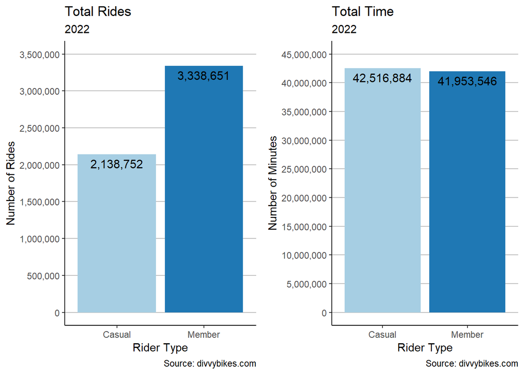

### 5.1.2 Average Ride Length

The casual ride length was ~58% longer than that of their member counterparts.

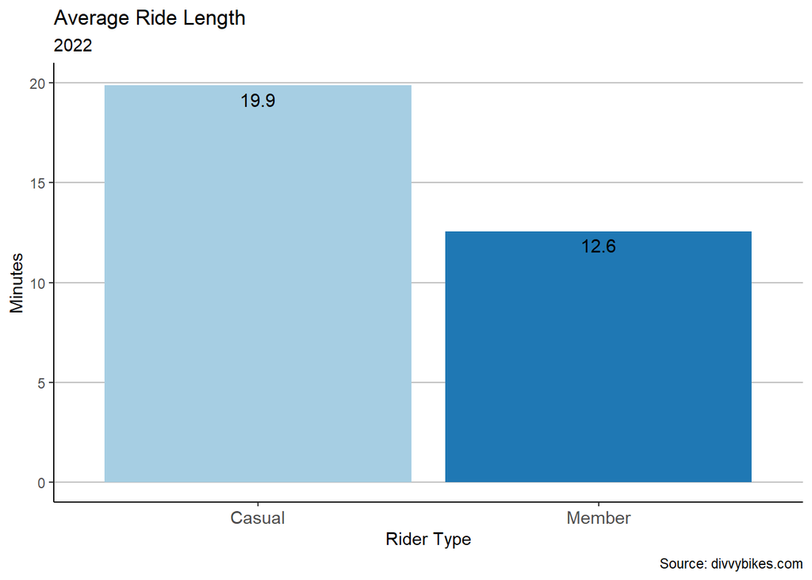

### 5.1.3 Total Rides By Ride Type

Members have a slight preference for the classic bike, while the casual rider prefers the electric bike.

```
## # A tibble: 4 × 3
## # Groups:   member_casual [2]
##   member_casual rideable_type       n
##   <fct>         <chr>           <int>
## 1 Casual        classic_bike   883283
## 2 Casual        electric_bike 1255469
## 3 Member        classic_bike  1704820
## 4 Member        electric_bike 1633831
```

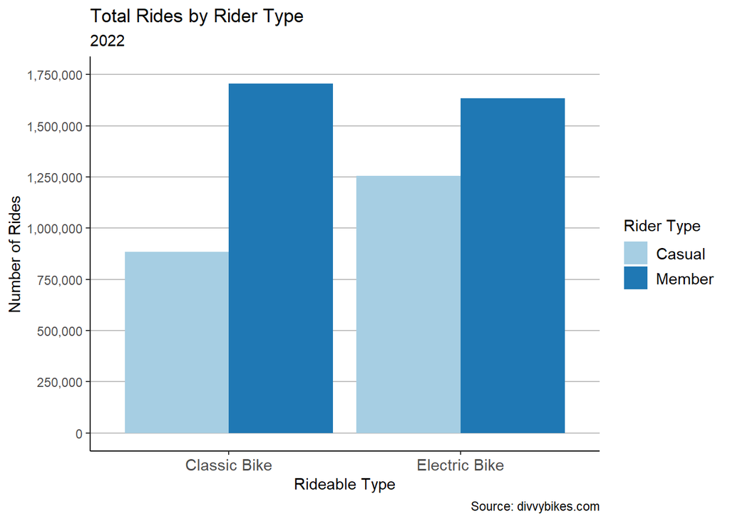

### 5.1.4 Average ride length by Rider and Bike Type.

Electric type ride lengths are shorter than their classic counterparts across both rider types.

```
## # A tibble: 4 × 3
## # Groups:   member_casual [2]
##   member_casual rideable_type average_mins
##   <fct>         <chr>                <dbl>
## 1 Casual        classic_bike          24.8
## 2 Casual        electric_bike         16.4
## 3 Member        classic_bike          13.5
## 4 Member        electric_bike         11.6
```

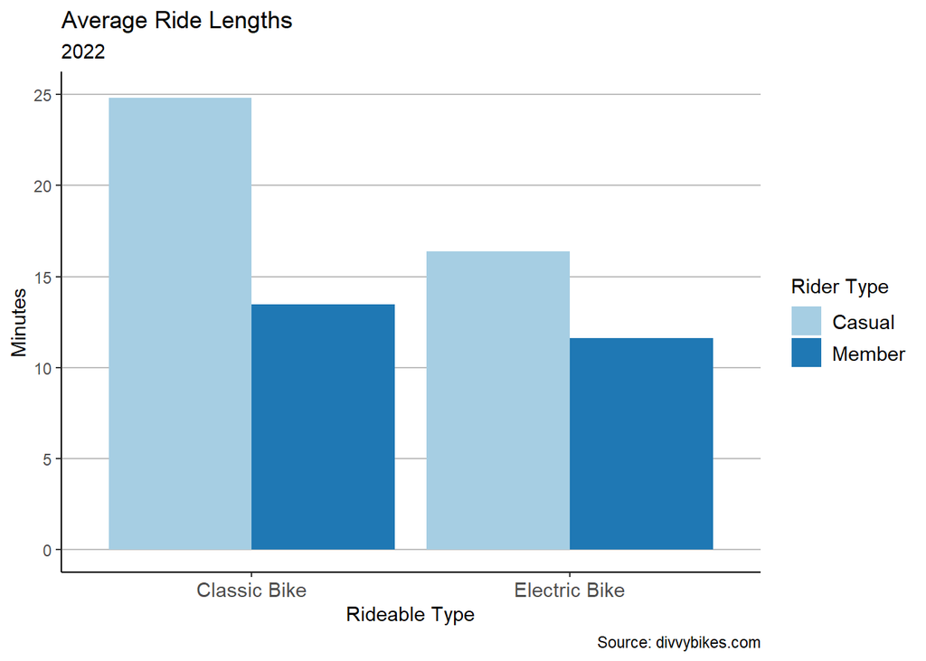

## 5.2 Monthly Analysis

### 5.2.1 Total Rides

Ridership peaks over the Summer months with the upswing beginning in May and falling off in November.

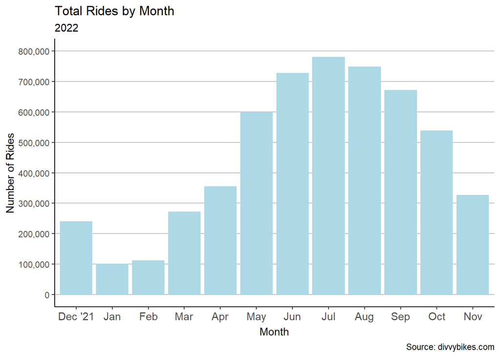

### 5.2.2 Ridership by Month

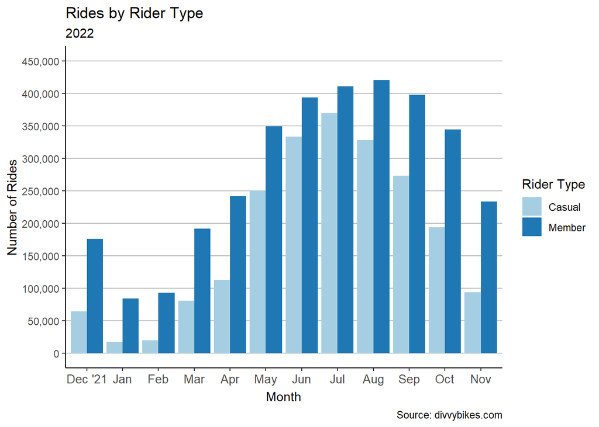

### 5.2.3 Percentage of Riders by Month

48% of annual casual rides occur from June to August.

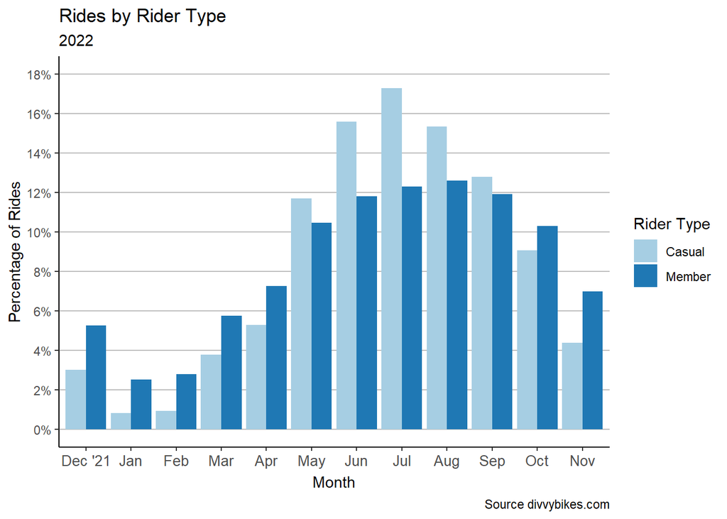

## 5.3 Day Of Week Analysis

### 5.3.1 Total Rides

Membership rides peak during mid-week while casual rides peak over the weekend.

Member and casual ridership appear to be inversely related. This is likely due to members using rides to get to and from work, whereas visitors are likely to vacation over the weekend and ride then.

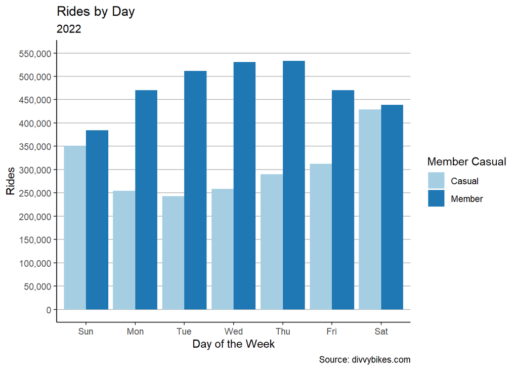

### 5.3.2 Casual Riders

The most popular days for casual riders is weekends June to August, peaking in July.

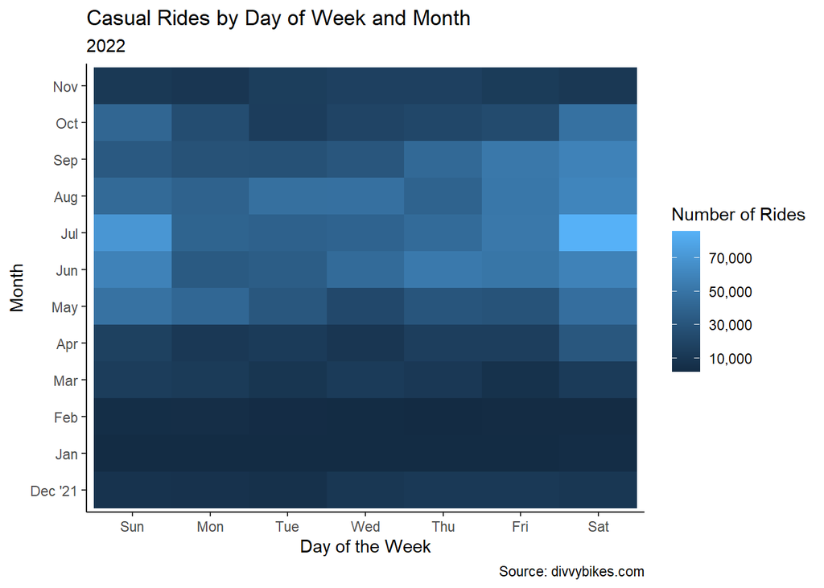

### 5.3.3 Member Riders

Member rides are more dispersed throughout the year but appear to peak Tuesday through Thursday, June to September.

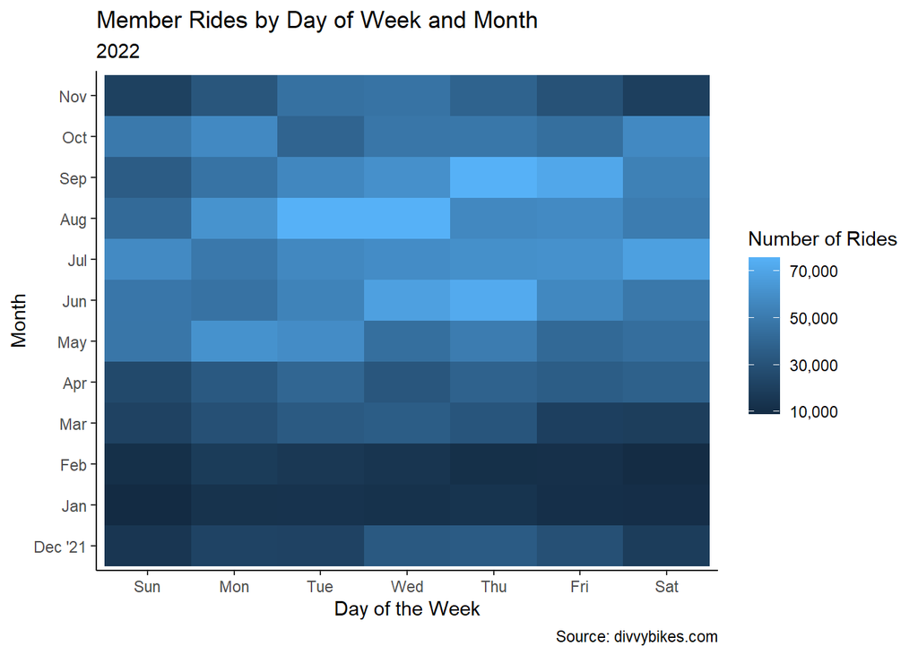

## 5.4 Time of Day

### 5.4.1 Rides by Hour

Ridership for members spikes in the morning and afternoon typical of work start and end times. Casual ridership gradually builds throughout he day peaking around 17:00.

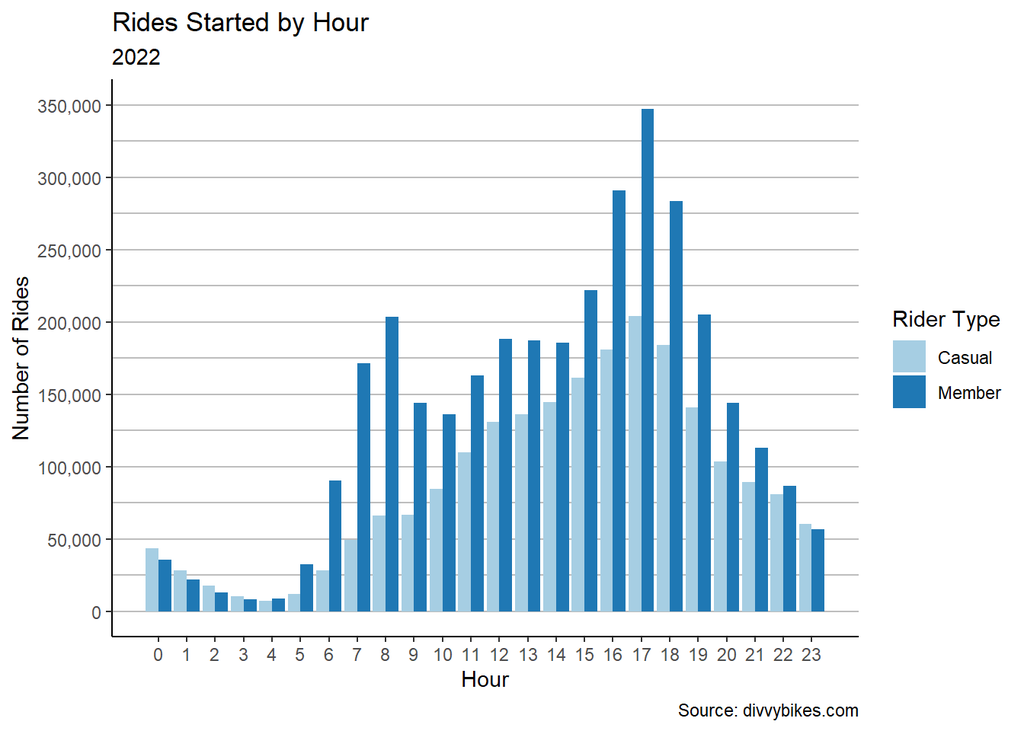

### 5.4.2 Percentage of Riders

Over half of all casual rides occur between 13:00 and 19:00.

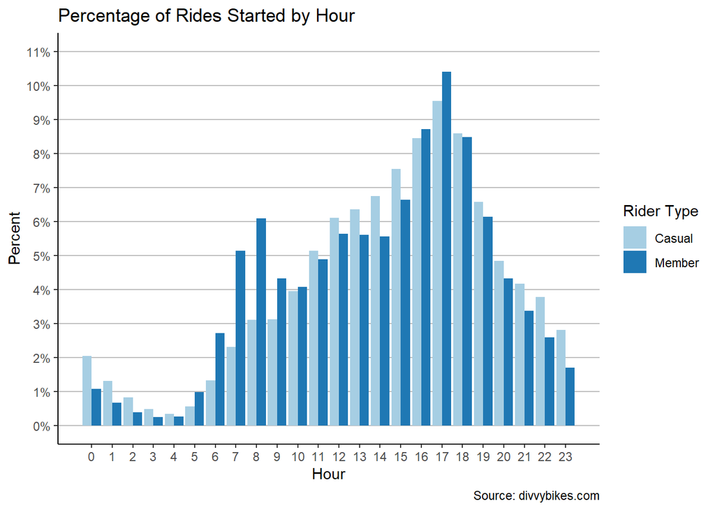

## 5.5 Stolen Bike Data

### 5.5.1 Stolen Bike Data Set

Bikes missing for longer than 24 hours can result in a $1,200 fee (plus tax) charged to the account holder that took out the bike.

```r
bike_data_stolen <-
  subset(bike_data_22, ride_length >= 86400)
```

### 5.5.2 Total Bikes Stolen

Total rides charged with a stolen bike fee. All rides that fit under this category were classic bikes interestingly enough.

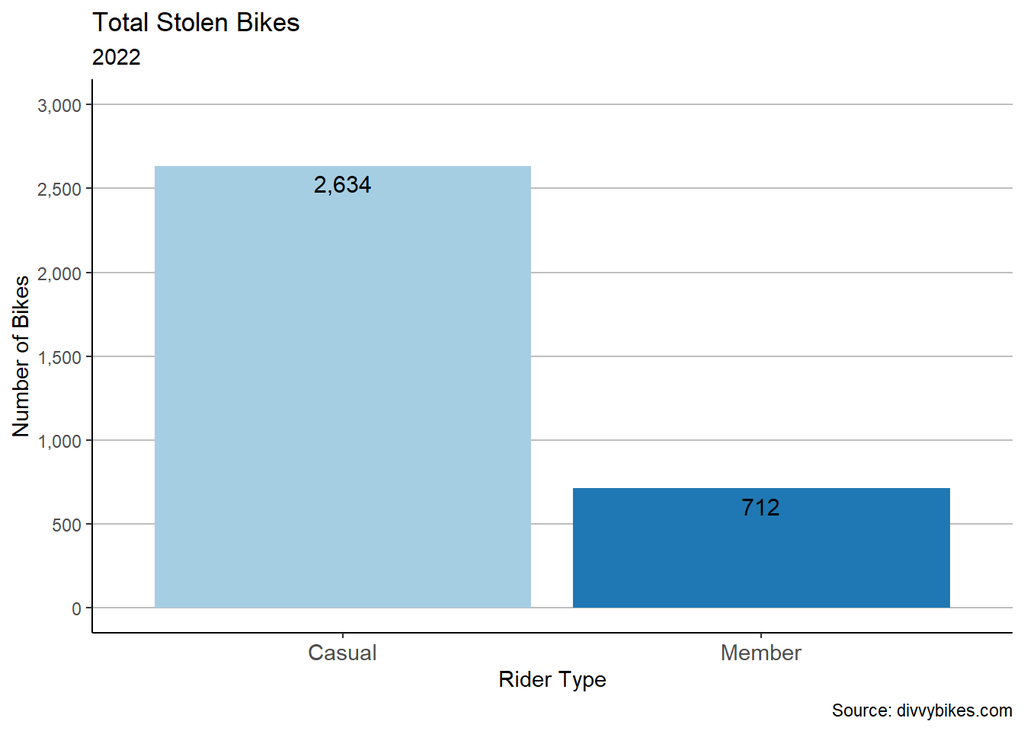

### 5.5.3 Stolen Bikes by Month

The number of rides charged a stolen bike fee correlated with the number of rides taken.

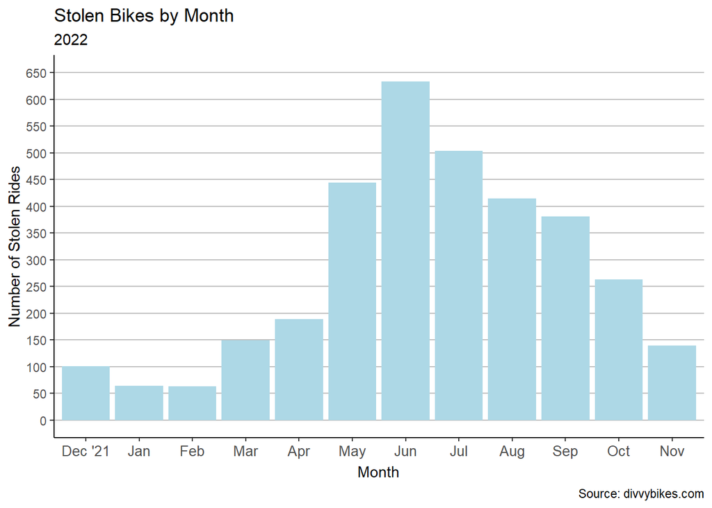

### 5.5.4 Stolen Bikes by Rider Type

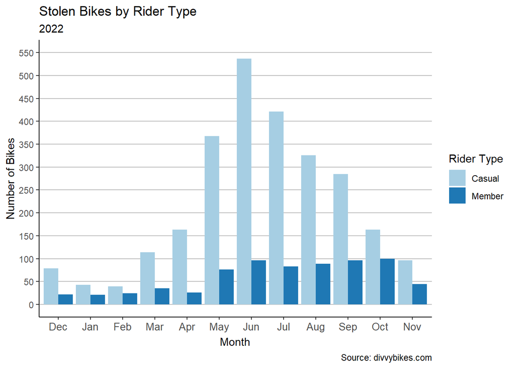

## 5.6 Cancelled Rides

### 5.6.1 Percentage of Rides

Member riders were more likely to cancel their rides than casual riders.

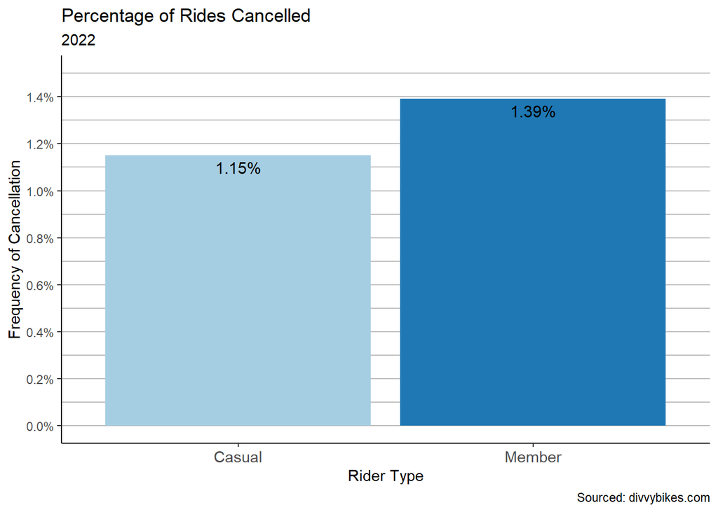

## 5.7 Trip Data

To more accurately group ride start locations GPS locations I rounded off the starting latitude and longitudes to the 4th decimal place.

At this decimal place it’s accurate within 30 feet and groups together locations that share the same station name but may have a different 5th decimal point.

```r
popular_rides$start_lat <-
  round(popular_rides$start_lat, digits = 4)

popular_rides$start_lng <-
  round(popular_rides$start_lng, digits = 4)

head(popular_rides)
```

```
## # A tibble: 6 × 6
##   start_station_name           end_station_name  ride_…¹ membe…² start…³ start…⁴
##   <chr>                        <chr>               <dbl> <chr>     <dbl>   <dbl>
## 1 Laflin St & Cullerton St     Morgan St & Polk…     455 member     41.9   -87.7
## 2 LaSalle Dr & Huron St        Clarendon Ave & …    1614 casual     41.9   -87.6
## 3 Halsted St & North Branch St Broadway & Barry…     766 member     41.9   -87.6
## 4 Halsted St & North Branch St LaSalle Dr & Hur…     883 member     41.9   -87.6
## 5 Leavitt St & Chicago Ave     Clark St & Drumm…    1216 member     41.9   -87.7
## 6 Wabash Ave & 16th St         Wells St & Polk …     567 member     41.9   -87.6
## # … with abbreviated variable names ¹ride_length, ²member_casual, ³start_lat,
## #   ⁴start_lng
```

### 5.7.1 Popular Start Locations

Here we will create a dataframe with the 5 most popular start stations for both casual and member riders.

```r
popular_start <- popular_rides %>%
  group_by(member_casual, start_station_name) %>%
  tally() %>%
  arrange(desc(n)) %>%
  slice(1:5)
```

#### 5.7.1.1 Casual Rides

The most popular starting locations for casual riders

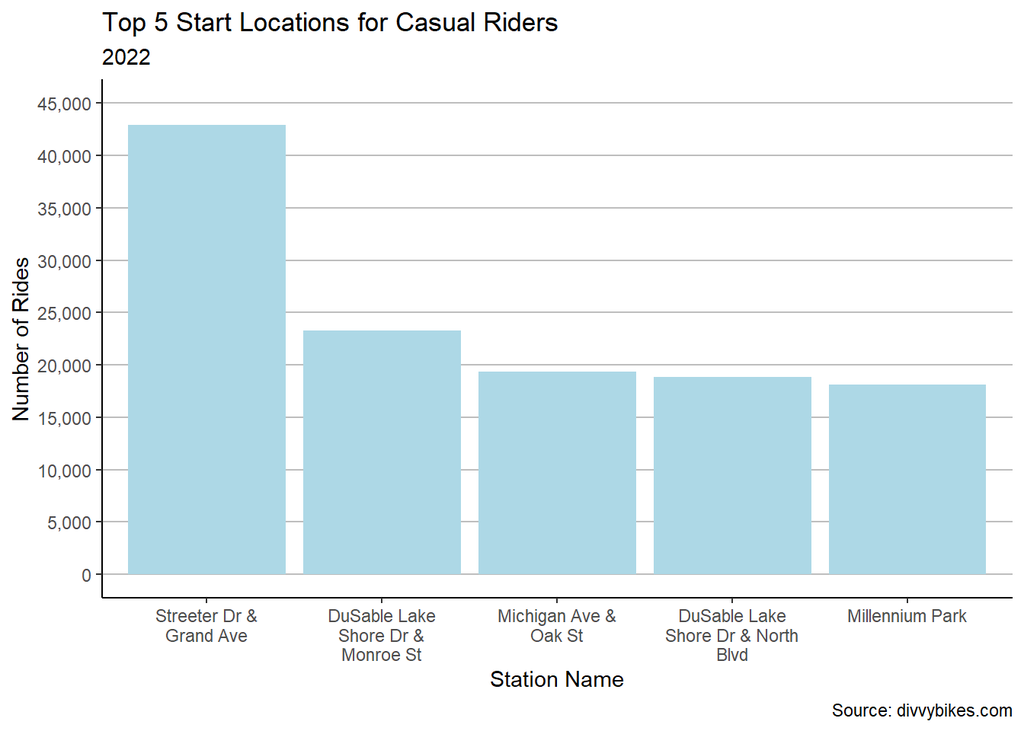

#### 5.7.1.2 Member Rides

The most popular starting locations for members

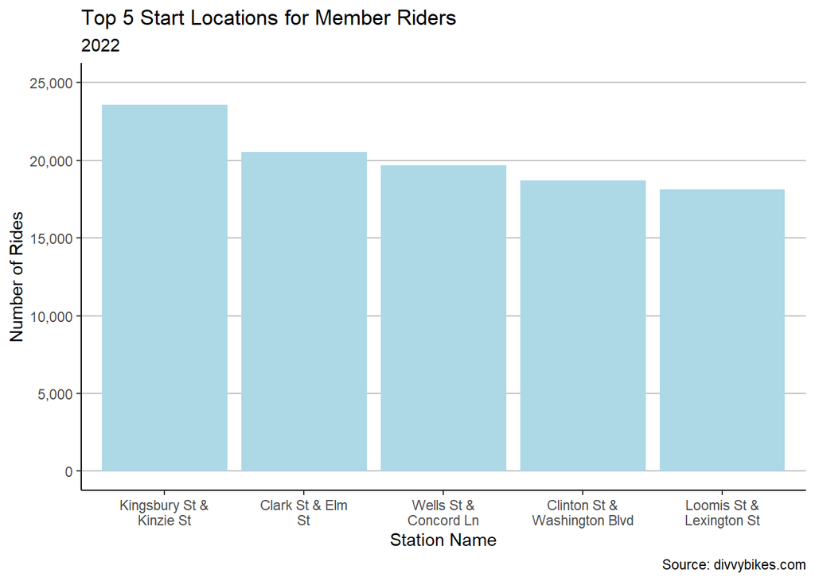

## 5.8 Mapping Popular Start Stations

```r
popular_casual <- popular_rides %>%
  filter(member_casual == "casual") %>%
  group_by(member_casual, start_station_name, start_lat, start_lng) %>%
  tally() %>%
  arrange(desc(n)) %>%
  group_by(member_casual) %>%
  slice(1:5)
```

```r
popular_member <- popular_rides %>%
  filter(member_casual == "member") %>%
  group_by(member_casual, start_station_name, start_lat, start_lng) %>%
  tally() %>%
  arrange(desc(n)) %>%
  group_by(member_casual) %>%
  slice(1:5)
```

### 5.8.1 Casual Rides

```r
#casual matrix
lon <- popular_casual$start_lng
lat <- popular_casual$start_lat
df <- as.data.frame(cbind(lon, lat))

#state which columns are lon and lat
coordinates(df) <- ~lon+lat

#convert to sf object
df <- st_as_sf(df)

#set crs
st_crs(df) <- 4326

#create leaflet
leaflet(df) %>% addMarkers() %>% addTiles()
```

[interactive chart not shown]

### 5.8.2 Member Rides

```r
# member matrix
lon <- popular_member$start_lng
lat <- popular_member$start_lat
df <- as.data.frame(cbind(lon, lat))

#state which columns are lon and lat
coordinates(df) <- ~lon+lat

#convert to sf object
df <- st_as_sf(df)

#set crs
st_crs(df) <- 4326

#create leaflet
leaflet(df) %>% addMarkers() %>% addTiles()
```

[interactive chart not shown]

### 5.8.3 Top 5 Trips by Rider Type

For the casual riders, 4 of the 5 most popular rides ended at the start station. All 5 of the start stations are the same as the popular start stations from the previous section.

The member riders however, shared no start station locations from the previous section. They also did not return to the start station.

```
## # A tibble: 10 × 4
## # Groups:   member_casual [2]
##    member_casual start_station_name                end_station_name            n
##    <chr>         <chr>                             <chr>                   <int>
##  1 casual        Streeter Dr & Grand Ave           Streeter Dr & Grand Ave  7468
##  2 casual        DuSable Lake Shore Dr & Monroe St DuSable Lake Shore Dr …  4536
##  3 casual        DuSable Lake Shore Dr & Monroe St Streeter Dr & Grand Ave  3897
##  4 casual        Michigan Ave & Oak St             Michigan Ave & Oak St    3259
##  5 casual        Millennium Park                   Millennium Park          2673
##  6 member        Ellis Ave & 60th St               University Ave & 57th …  5948
##  7 member        University Ave & 57th St          Ellis Ave & 60th St      5617
##  8 member        Ellis Ave & 60th St               Ellis Ave & 55th St      5244
##  9 member        Ellis Ave & 55th St               Ellis Ave & 60th St      4690
## 10 member        State St & 33rd St                Calumet Ave & 33rd St    3222
```

## 5.9 Rides Returned to Start Station

Mutating table to include a column to indicate if bike was returned to the start station and dropping those missing station names

```r
# return status column

return_status <-
  popular_rides %>%
  mutate(status = case_when(
    start_station_name == end_station_name ~ "Returned",
    start_station_name != end_station_name ~ "Not Returned"))


print(head(return_status[c("start_station_name", "end_station_name", "status")]))
```

```
## # A tibble: 6 × 3
##   start_station_name           end_station_name           status
##   <chr>                        <chr>                      <chr>
## 1 Laflin St & Cullerton St     Morgan St & Polk St        Not Returned
## 2 LaSalle Dr & Huron St        Clarendon Ave & Leland Ave Not Returned
## 3 Halsted St & North Branch St Broadway & Barry Ave       Not Returned
## 4 Halsted St & North Branch St LaSalle Dr & Huron St      Not Returned
## 5 Leavitt St & Chicago Ave     Clark St & Drummond Pl     Not Returned
## 6 Wabash Ave & 16th St         Wells St & Polk St         Not Returned
```

### 5.9.1 Percentage of Returned Bikes to Start Station

Casual riders unsurprisingly returned to their starting station at a much higher frequency than member riders, implying that their rides were driven more by sight seeing than a destination. This may also help to offer an explanation as to why their average ride times were longer on average as well.

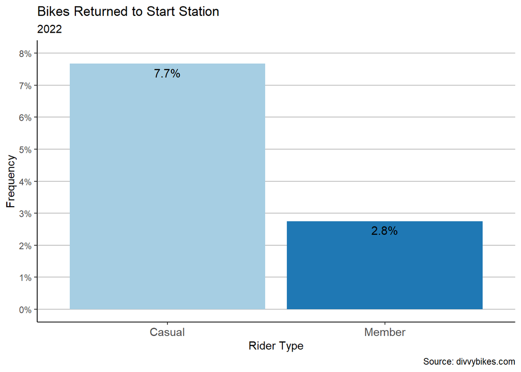

## 5.10 Price Breakdown

Divvy Bikes offer annual memberships for /$120 a year. Included with this membership are unlimited classic bike rentals under 45 minutes and all bike unlock fees. Electric bike rentals are also offered at a reduced ride price per minute compared to casual riders.

```r
electric <- read_csv("C:\\Users\\brein\\OneDrive\\Documents\\Coursera\\Datay_Analytics\\captstone_02\\divvy_calc_electric.csv")
classic <- read_csv("C:\\Users\\brein\\OneDrive\\Documents\\Coursera\\Datay_Analytics\\captstone_02\\divvy_calc_classic.csv")
```

### 5.10.1 Electric Bike

The average ride length for a casual rider on an electric bike is ~ 16 minutes. The casual rider pays $1 to unlock a bike and $0.39 a minute per minute, while the member rider unlocks bikes for free and pays only $0.16 per minute.

After 26 rides, just over 2 rides per month members will start to save.

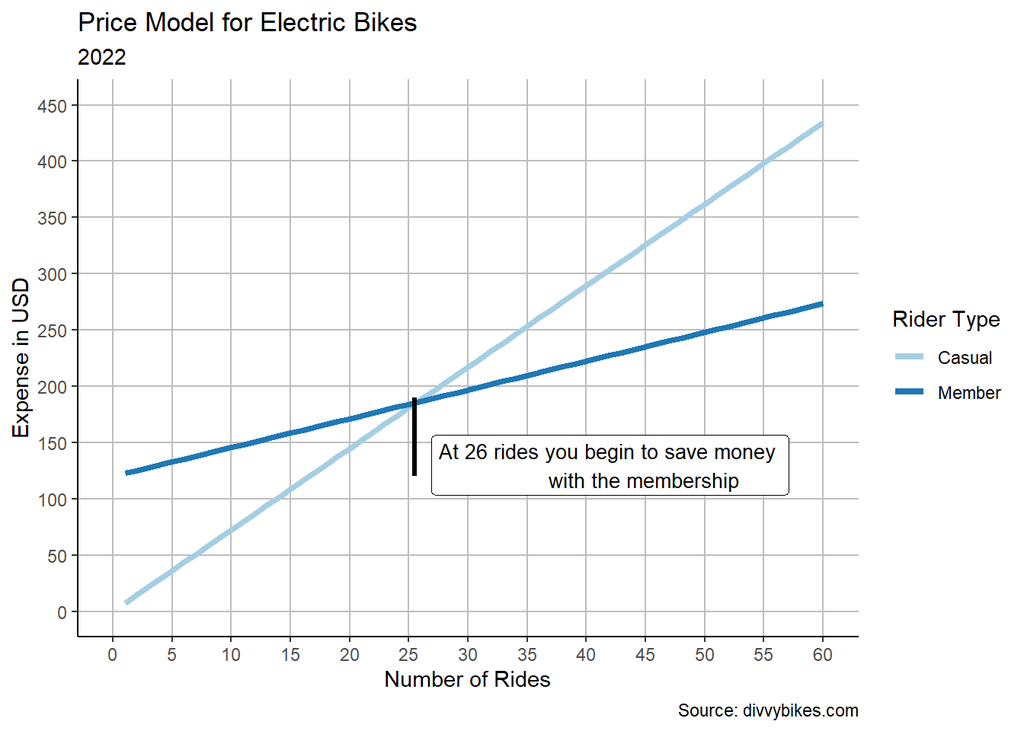

### 5.10.2 Classic Bike

The average classic ride for casual and member riders is 24 minutes and 13 minutes respectively. For members each Classic ride less than 45 minutes is completely included with the cost of membership. So if a member was to only ride classic bikes for the year, they’re price would likely be fixed at the $120 membership fee.

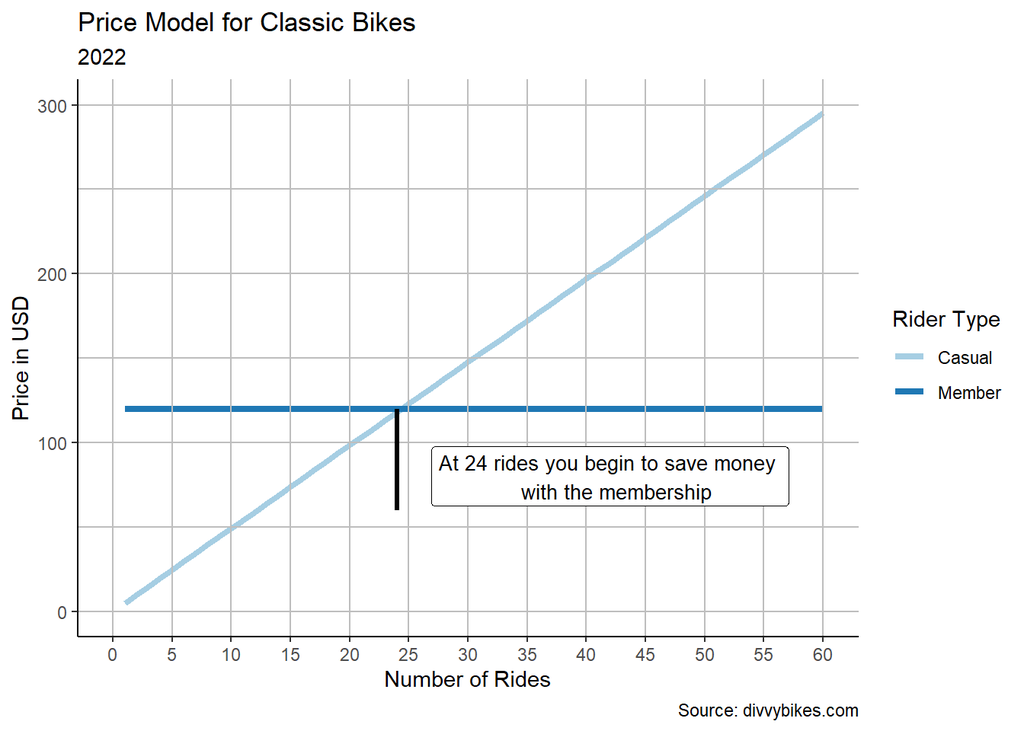

# 6 Act

## 6.1 Recommendations

1. Customers are usually drawn to memberships by the idea of saving money. If they are local casual riders, apprising them of the price models where after just 2 rides a month they’ll begin to save money could effectively persuade them to become members.
2. One of the larger isolated pools of riders begins at the University of Chicago campus. Targeting students not yet part of the membership program via digital media could be a good source of potential members as they are likely to be reoccurring riders.
3. The most popular trips for casual riders begin and end at the same station, most often at waterfront attractions. It may be conducive to increase the number of stations or bikes available per station in these areas.

## 6.2 Future Notes

- Unfortunately without user information it makes it difficult to measure how many users are local to Chicago versus those that travel, and therefore would be more likely to be persuaded into purchasing a membership.
- Being able to identify the type of ride pass would also allow for a more insightful analysis, as the raw data only indicates rider type.
- More specific station data could also help with further analysis, for example the average time and number of docking stations available.